# RPU 2013 Analyse

## Ensemble des SAU

attente en mn:

```r
e <- ymd_hms(d1$ENTREE)
s <- ymd_hms(d1$SORTIE)
q <- s - e
d1$passage <- q/60

tapply(d1$passage, d1$FINESS, mean, na.rm = TRUE)
```

```
##    3Fr    Alk    Col    Dia    Geb    Hag    Hus    Mul    Odi    Sel
## 135.94 156.18 168.02 160.29  76.40 351.89  61.78 179.46  94.39 159.32
##    Wis    Sav
## 132.53 151.46
```

```r
tapply(d1$passage, d1$FINESS, sd, na.rm = TRUE)
```

```
##   3Fr   Alk   Col   Dia   Geb   Hag   Hus   Mul   Odi   Sel   Wis   Sav
## 154.8 183.0 176.3 140.5 128.1 327.3 248.9 138.2 108.3 102.0 153.9 154.4
```

```r
tapply(d1$passage, d1$FINESS, median, na.rm = TRUE)
```

```
## 3Fr Alk Col Dia Geb Hag Hus Mul Odi Sel Wis Sav
## 107 110 119 135  50 235   1 144  75 135  93 112
```

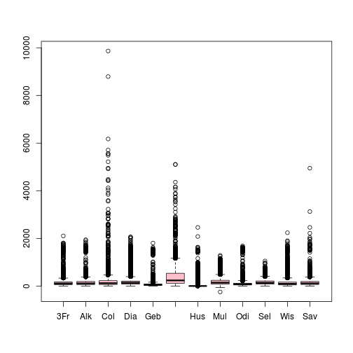

```r
boxplot(as.numeric(d1$passage) ~ d1$FINESS, col = "pink")
```

attente de moins d'une journée:

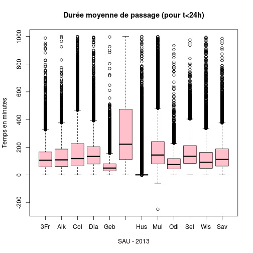

```r
h24 <- d1[as.numeric(d1$passage) < 1000, c("passage", "FINESS")]
boxplot(as.numeric(h24$passage) ~ h24$FINESS, col = "pink", main = "Durée moyenne de passage (pour t<24h)",
    ylab = "Temps en minutes", xlab = "SAU - 2013")
```

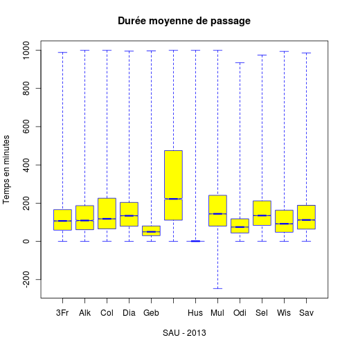

```r
boxplot(as.numeric(h24$passage) ~ h24$FINESS, col = "yellow", range = 0, notch = TRUE,
    border = "blue", main = "Durée moyenne de passage", ylab = "Temps en minutes",
    xlab = "SAU - 2013")
```

# Maladies infectieuses

Codes CIM 10:

| Regroupement | Code CIM 10 | Description |
| --- | --- | --- |
| Hyperthermies | T67 | Effets de la chaleur et de la lumière |
| Hyperthermies | X30 | Exposition à une chaleur naturelle excessive |
| Déshydratations | E86 | Hypovolémie |
| Hyponatrémies | E871 | Hypo-osmolarité et hyponatrémie |
| Malaises | R42 | Etourdissements et éblouissements |
| Malaises | R53 | Malaise et fatigue |
| Malaises | R55 | Syncope et collapsus |
| Asthme | J45 | Asthme |
| Asthme | J46 | Etat de mal asthmatique |
| Piqûres arthropodes ou autres | T63 | Effet toxique d’un contact avec un animal venimeux |
| Piqûres arthropodes ou autres | W57 | Morsure ou piqûre non venimeuse d’insectes et arthropodes |
| Piqûres arthropodes ou autres | X20→X29 | Contact avec des animaux ou des plantes venimeuses |

Pendant toute la durée du Plan Canicule, du 1er juin au 31 août.

on veut mettre 3 graphiques sur le même dessin

```r
par(mfrow = c(3, 1))
```

## gastro

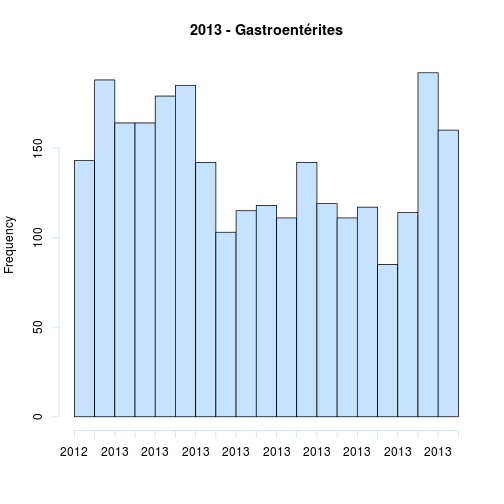

```r
gastro <- d1[substr(d1$DP, 1, 3) == "A09", c("DP", "ENTREE")]
g <- gastro[complete.cases(gastro), ]
g$date <- as.Date(g$ENTREE)
hist(g$date, breaks = 18, freq = TRUE, col = "slategray1", main = "2013 - Gastroentérites",
    xlab = "")
```

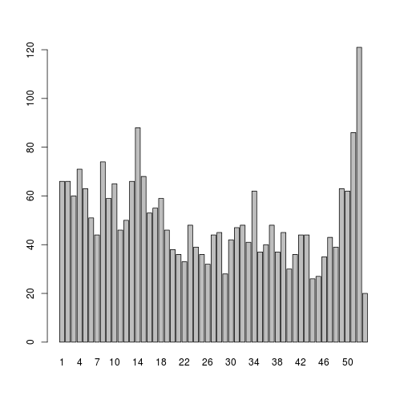

```r
g$date2 <- ymd_hms(g$ENTREE)
wg <- week(g$date2)
barplot(summary(as.factor(wg)))
```

## bronchiolite

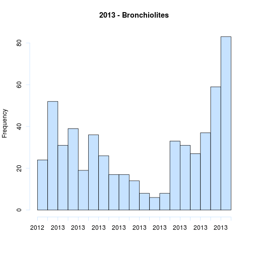

```r
bronchio <- d1[substr(d1$DP, 1, 3) == "J21", c("DP", "ENTREE")]
bronchio <- bronchio[complete.cases(bronchio), ]
bronchio$date <- as.Date(bronchio$ENTREE)
hist(bronchio$date, breaks = 18, freq = TRUE, col = "slategray1", main = "2013 - Bronchiolites",
    xlab = "")
```

## Grippe

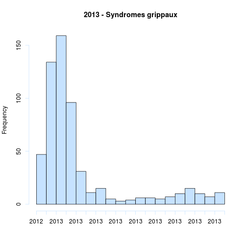

```r
grippe <- d1[substr(d1$DP, 1, 3) == "J11" | substr(d1$DP, 1, 3) == "J10" | substr(d1$DP,
    1, 3) == "J09", c("DP", "ENTREE")]
grippe <- grippe[complete.cases(grippe), ]
grippe$date <- as.Date(grippe$ENTREE)
hist(grippe$date, breaks = 18, freq = TRUE, col = "slategray1", main = "2013 - Syndromes grippaux",
    xlab = "")
```

```r
par(mfrow = c(1, 1))
```

## malaises

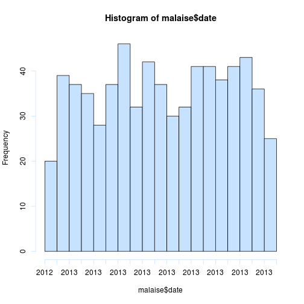

```r
malaise <- d1[substr(d1$DP, 1, 3) == "R55", c("DP", "ENTREE")]
malaise <- malaise[complete.cases(malaise), ]
malaise$date <- as.Date(malaise$ENTREE)
hist(malaise$date, breaks = 18, freq = TRUE, col = "slategray1")
```

malaise selon INVS (canicule):

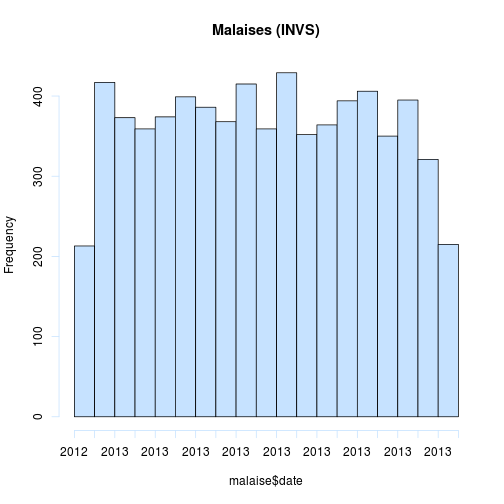

```r
malaise <- d1[substr(d1$DP, 1, 3) == "R55" | substr(d1$DP, 1, 3) == "R53" |
    substr(d1$DP, 1, 3) == "R42", c("DP", "ENTREE")]
malaise <- malaise[complete.cases(malaise), ]
malaise$date <- as.Date(malaise$ENTREE)
hist(malaise$date, breaks = 18, freq = TRUE, col = "slategray1", main = "Malaises (INVS)")
```

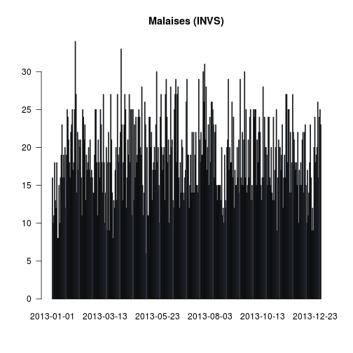

```r
plot(as.factor(malaise$date), col = "slategray1", las = 1, main = "Malaises (INVS)")
```

## AVC

code SIM10: I60 à I64 **complete.cases** permet de supprimer les enregistrements vides

```r
avc <- d1[substr(d1$DP, 1, 3) >= "I60" & substr(d1$DP, 1, 3) <= "I64", c("DP",
    "ENTREE", "FINESS", "AGE", "SEXE")]
avc <- avc[complete.cases(avc), ]
nrow(avc)
```

```
## [1] 2002
```

```r
summary(avc$FINESS)
```

```
## 3Fr Alk Col Dia Geb Hag Hus Mul Odi Sel Wis Sav
##  48  11 443   0  16 431 316 500   1 171  65   0
```

```r
summary(avc$AGE)
```

```
##    Min. 1st Qu.  Median    Mean 3rd Qu.    Max.
##     1.0    63.0    76.0    72.5    84.0   112.0
```

```r
summary(avc$SEXE)
```

```
##    F    I    M
## 1069    0  933
```

Le SAU des HUS reçoit peu d' AVC alors que c'est la meilleure filière. Les résultats sont faussés par l'UNV.

## Douleur thoracique

code SIM10: I20 à I25

```r
idm <- d1[substr(d1$DP, 1, 3) >= "I20" & substr(d1$DP, 1, 3) <= "I25", c("DP",
    "ENTREE", "FINESS", "AGE", "SEXE")]
idm <- idm[complete.cases(idm), ]
nrow(idm)
```

```
## [1] 994
```

```r
summary(idm$FINESS)
```

```
## 3Fr Alk Col Dia Geb Hag Hus Mul Odi Sel Wis Sav
##  74  10 147   0  34 152 311 133   2  77  54   0
```

```r
summary(idm$AGE)
```

```
##    Min. 1st Qu.  Median    Mean 3rd Qu.    Max.
##     0.0    53.2    65.0    65.3    80.0   103.0
```

```r
summary(idm$SEXE)
```

```
##   F   I   M
## 387   0 607
```

## Lésions traumatiques

codes CIM10 S00–T98

```r
trauma <- d1[substr(d1$DP, 1, 3) >= "S00" & substr(d1$DP, 1, 3) <= "T98", c("DP",
    "ENTREE", "FINESS", "AGE", "SEXE")]
trauma <- trauma[complete.cases(trauma), ]
nrow(trauma)
```

```
## [1] 85588
```

```r
summary(trauma$FINESS)
```

```
##   3Fr   Alk   Col   Dia   Geb   Hag   Hus   Mul   Odi   Sel   Wis   Sav
##  5451  2795 23701     0  7496 11426  1716 11812  3550 13431  4210     0
```

```r
summary(trauma$AGE)
```

```
##    Min. 1st Qu.  Median    Mean 3rd Qu.    Max.
##     0.0    13.0    28.0    34.1    51.0   112.0
```

```r
summary(trauma$SEXE)
```

```
##     F     I     M
## 37136     3 48449
```

```r
geb <- d1[d1$FINESS == "Geb", ]
```

Orientation des patients

```r
summary(geb$MODE_SORTIE)
```

```
##        NA  Mutation Transfert  Domicile     Décès      NA's
##         0       315       197      7748         0      6843
```

```r
summary(geb$ORIENTATION)
```

```
##  CHIR FUGUE   HDT    HO   MED  OBST   PSA   REA   REO    SC  SCAM    SI
##    59     3     1     3    29     4    40     2     1     6    33    10
##  UHCD  NA's
##    26 14886
```

Mode d'arrivée aux urgences:

```r
summary(as.factor(geb$TRANSPORT))
```

```
##  AMBU PERSO  SMUR  VSAB  NA's
##  1317 12749     1   899   137
```

Heure d'arrivée aux urgences

```r
e <- ymd_hms(geb$ENTREE)
h <- hour(e)
summary(h)
```

```
##    Min. 1st Qu.  Median    Mean 3rd Qu.    Max.
##       0      10      14      14      18      23
```

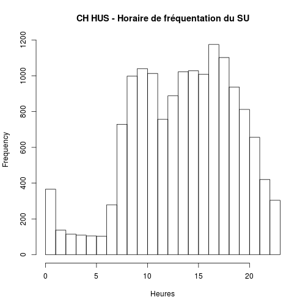

```r
hist(h, breaks = 23, xlab = "Heures", main = "CH HUS - Horaire de fréquentation du SU")
```

```
## 103 1175
```

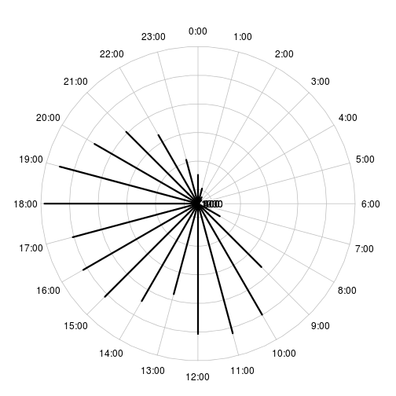

```
## 200 400 600 800 1000 1200
```

```r
t <- table(h)
t2 <- as.integer(t)
c <- clock24.plot(t2, clock.pos = 1:24, lwd = 3)
```

```
## 103 1175
```

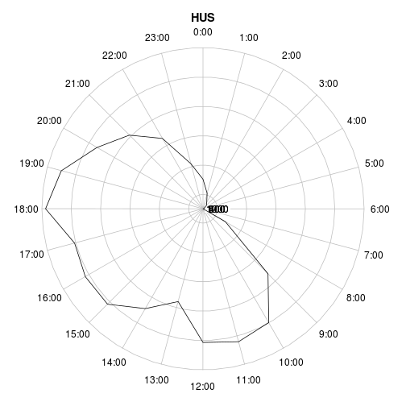

```
## 200 400 600 800 1000 1200
```

```r
c <- clock24.plot(t2, clock.pos = 1:24, rp.type = "p", main = "HUS", xlab = "Heures d'arrivée aux urgences",
    show.grid.labels = F)
```

```
## 103 1175
```

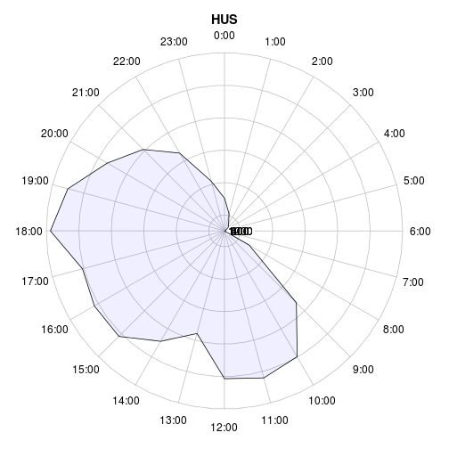

```
## 200 400 600 800 1000 1200
```

```r
# nécessite la librairie openintro
clock24.plot(t2, clock.pos = 1:24, rp.type = "p", main = "HUS", xlab = "Heures d'arrivée aux urgences",
    show.grid.labels = F, poly.col = fadeColor("blue", fade = "10"))
```

```
## 103 1175
```

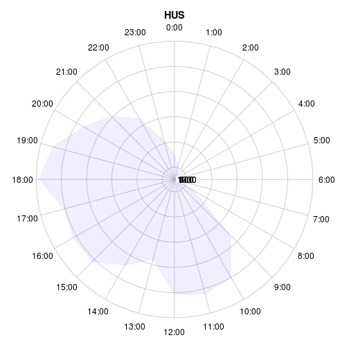

```
## 200 400 600 800 1000 1200
```

```r
clock24.plot(t2, clock.pos = 1:24, rp.type = "p", main = "HUS", xlab = "Heures d'arrivée aux urgences",
    show.grid.labels = F, poly.col = fadeColor("blue", fade = "10"), line.col = fadeColor("blue",
        fade = "10"))
```

Idem pour les sorties

```
## 74 1169
```

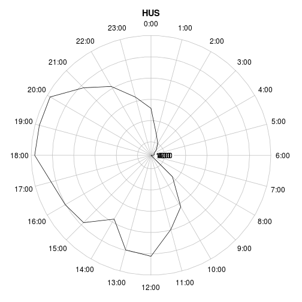

```
## 200 400 600 800 1000 1200
```

```r
s <- ymd_hms(geb$SORTIE)
t3 <- as.integer(table(hour(s)))
clock24.plot(t3, clock.pos = 1:24, rp.type = "p", main = "HUS", xlab = "Heures de sortie des urgences",
    show.grid.labels = F)
```

Combinaison entrée-sortie

```
## 74 1175
```

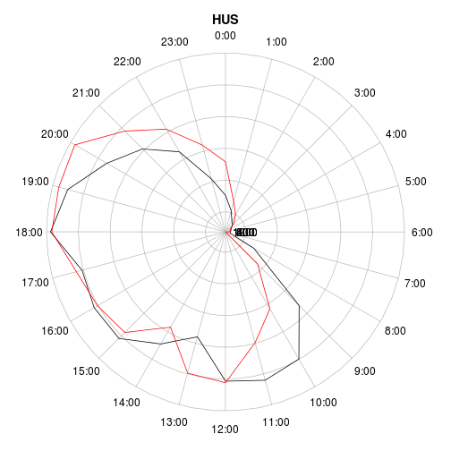

```
## 200 400 600 800 1000 1200
```

```r
t4 <- rbind(t2, t3)
clock24.plot(t4, clock.pos = 1:24, rp.type = "p", main = "HUS", xlab = "Heures d'arrivée aux urgences",
    show.grid.labels = F)
```

```
## 74 1175
```

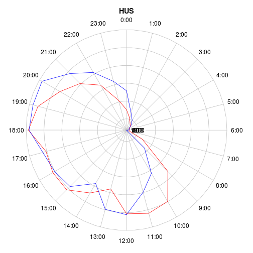

```
## 200 400 600 800 1000 1200
```

```r
clock24.plot(t4, clock.pos = 1:24, rp.type = "p", main = "HUS", xlab = "Heures d'arrivée aux urgences",
    show.grid.labels = F, line.col = c("red", "blue"))
```

```
## 74 1175
```

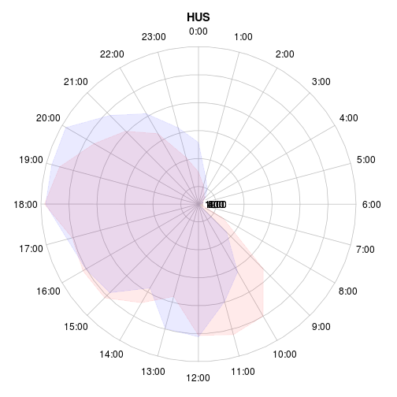

```
## 200 400 600 800 1000 1200
```

```r
fadeBlue <- fadeColor("blue", fade = "15")
fadeRed <- fadeColor("red", fade = "15")
clock24.plot(t4, clock.pos = 1:24, rp.type = "p", main = "HUS", xlab = "Heures d'arrivée aux urgences",
    show.grid.labels = F, line.col = c(fadeRed, fadeBlue), poly.col = c(fadeRed,
        fadeBlue))
```

Entrées selon la période du jour: nuit profonde NP (0h-8h = 1), journée JO (8h-20h = 2), soir SR (20h-24h = 3). La date/heure d'entrée est transformée en heure entière par la fonction *hour*. hest à son tour segmenté en 3 périodes.

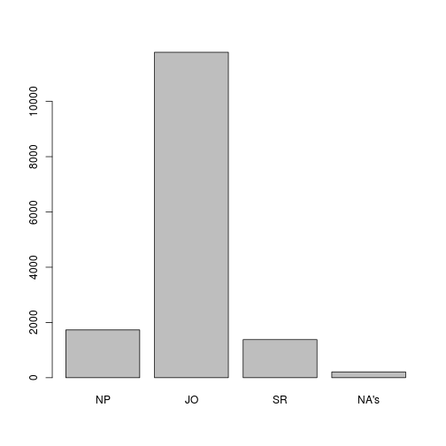

```r
e <- ymd_hms(geb$ENTREE)
h <- hour(e)
b <- cut(h, c(0, 8, 20, 24), labels = c("NP", "JO", "SR"))
bp <- summary(as.factor(b))
barplot(bp)
```

```r
round(prop.table(bp) * 100, 2)
```

```
##    NP    JO    SR  NA's
## 11.46 78.00  9.14  1.40
```

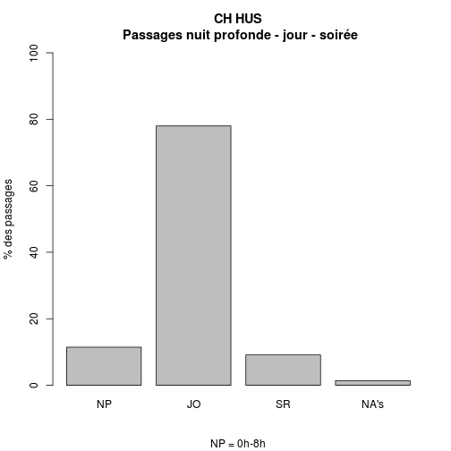

```r
barplot(round(prop.table(bp) * 100, 2), ylab = "% des passages", sub = "NP = 0h-8h",
    ylim = c(0, 100), main = "CH HUS\n Passages nuit profonde - jour - soirée")
```

```r
t <- table(geb$GRAVITE, b)
t
```

```
##    b
##        NP    JO    SR
##   1    96   698    78
##   2  1610 10974  1290
##   3    16    56     3
##   4     4    12     3
##   5     1     1     1
##   D     0     1     0
##   P     4    21     3
```

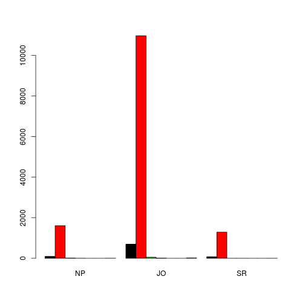

```r
barplot(t, beside = T, col = 1:7)
```

Mode sortie en fonction de la période

```r
t <- table(geb$MODE_SORTIE, b)
t
```

```
##            b
##               NP   JO   SR
##   NA           0    0    0
##   Mutation    78  189   30
##   Transfert   37  145   12
##   Domicile   827 6470  391
##   Décès        0    0    0
```

```r
t <- table(geb$ORIENTATION, b)
```